# Measuring Oral Reading Fluency: A Case for Samejima’s Continuous Response Model

item response theory

continuous response model

Stan

R

2019

I pitched the idea of using Samejima’s Continuous Response Model (CRM) to measure the Oral Reading Fluency (ORF) a while ago when I published a paper in 2012. In that paper, I used an ORF dataset from the Minneapolis Public Schools District (MPS) as a real data example. Since then, I don’t think anybody has bought the idea of using CRM to measure ORF, so here I am trying one more time with some accessible R code.

Cengiz Zopluoglu (University of Miami)  
12-31-2019

I pitched the idea of using Samejima’s [Continuous Response Model (CRM)](https://link.springer.com/article/10.1007/BF02291114) to measure the [Oral Reading Fluency (ORF)](https://council-for-learning-disabilities.org/what-is-oral-reading-fluency-verbal-reading-proficiency) a while ago when I published [a paper](https://link.springer.com/article/10.3758/s13428-012-0229-6) as a graduate student. In that paper, I used an ORF dataset from the Minneapolis Public Schools Disctrict (MPS) as a real data example. Since then, I don’t think anybody has bought the idea for using CRM to measure ORF, so here I am trying one more time with some accessible R code.

The ORF dataset from MPS was the only reason I was interested in CRM at all. During my second year in graduate school, I had a chance to complete a semester-long internship in MPS. The task I was assigned was to use IRT for scaling an ORF dataset they had. The dataset had three variables representing the number of words read correctly per minute for three different reading passages. There were 2594 students. Below is a little information about the dataset.

```r
str(wpm)
```

```
'data.frame':   2594 obs. of  3 variables:
 $ spas1wpm: num  66 33 101 14 22 47 67 49 35 41 ...
 $ spas2wpm: num  74 30 117 12 17 53 58 39 36 42 ...
 $ spas3wpm: num  74 29 110 11 23 38 71 36 26 45 ...
 - attr(*, "na.action")= 'omit' Named int [1:276] 13 32 39 50 53 56 105 108 136 152 ...
  ..- attr(*, "names")= chr [1:276] "13" "32" "39" "50" ...
```

```r
head(wpm)
```

```
  spas1wpm spas2wpm spas3wpm
1       66       74       74
2       33       30       29
3      101      117      110
4       14       12       11
5       22       17       23
6       47       53       38
```

```r
require(psych)

describe(wpm)[,c("n","mean","sd","min","max","skew","kurtosis")]
```

```
            n  mean    sd min max skew kurtosis
spas1wpm 2594 63.32 35.44   1 200 0.52    -0.22
spas2wpm 2594 70.09 45.34   3 236 0.84     0.20
spas3wpm 2594 64.93 42.95   2 230 0.86     0.27
```

```r
cor(wpm)
```

```
          spas1wpm  spas2wpm  spas3wpm
spas1wpm 1.0000000 0.9396532 0.9375107
spas2wpm 0.9396532 1.0000000 0.9657391
spas3wpm 0.9375107 0.9657391 1.0000000
```

At the time, I had taken an IRT course and knew a little bit about dichotomous and polytomous IRT models. It was a challenge because the measurement outcomes were kind of continuous. As I didn’t know much about CRM at that time and how to deal with this, I created discrete categories for each variable such that Level 1 (0-50 words), Level 2(51-100 words), Level 3 (101-150 words), Level 4 (151-200 words), and Level 5 (201-250 words). Then, I fit polytomous IRT models and did usual IRT modeling based on the best fitting model. I completed the internship but I was not satisfied as there was so much information thrown away by discretizing. That’s how I ended up exploring and discovering CRM and started working on it. I first briefly introduce the model before demonstrating how to use it for ORF data.

## Continuous Response Model

Below is the reparameterized version of the model by [Wang and Zeng (1998)](https://journals.sagepub.com/doi/abs/10.1177/014662169802200402). In this model, the probability of an individual with a latent parameter $\theta_i$ obtaining a score of $x$ or higher on an item with three parameters ($a$, $b$, and $\alpha$) is specified as,

$$P_{ij}(X\geq x|\theta_{i},a_j,b_j,\alpha_j)=\frac{1}{\sqrt{2\pi}}\int_{-\infty}^{v}{e^{-\frac{t^2}{2}}dt}$$

$$v=a_j\times (\theta_i-b_j-\frac{1}{\alpha_j}ln\frac{x}{k-x})$$
, where $k_j$ is the maximum possible score for the item. The parameter $a$ and $b$ have a very similar interpretation as in the 2PL IRT model. The $a$ parameter controls the steepness, and the $b$ parameter controls the location of the operating characteristic curves. There is an extra $\alpha$ parameter called “scaling parameter,” and it controls the distance among the curves.

Let’s create some plots to see it better. Suppose there is an item with ten categories, and this item has the following parameters: $a=1$, $b=0$, and $\alpha=1$.The figure below displays how the operating characteristic curves look like for this item. Note that there are nine lines in the plot indicating $P(X\geq 1)$, $P(X\geq 2)$, $P(X\geq 3)$, …, $P(X\geq 9)$.

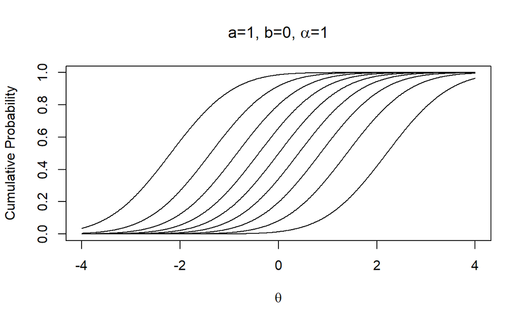

```r
 theta <- seq(-4,4,.01)

 a     = 1
 b     = 0
 alpha = 1

 x    <- 1
 k    <- 10
 v    <- a*(theta-b-(1/alpha)*log(x/(k-x)))
 plot(theta,pnorm(v,0,1),type="l",xlim=c(-4,4),ylim=c(0,1),
      main=expression(paste("a=1, b=0, ",alpha,"=1")),
      xlab=expression(theta),ylab="Cumulative Probability")

 for(x in 2:(k-1)){
     v    <- a*(theta-b-(1/alpha)*log(x/(k-x)))
     points(theta,pnorm(v,0,1),type="l")
 }
```

Now, let’s keep everything the same but increase the value of the parameter $a$ to 3, and we see how steepness changes.

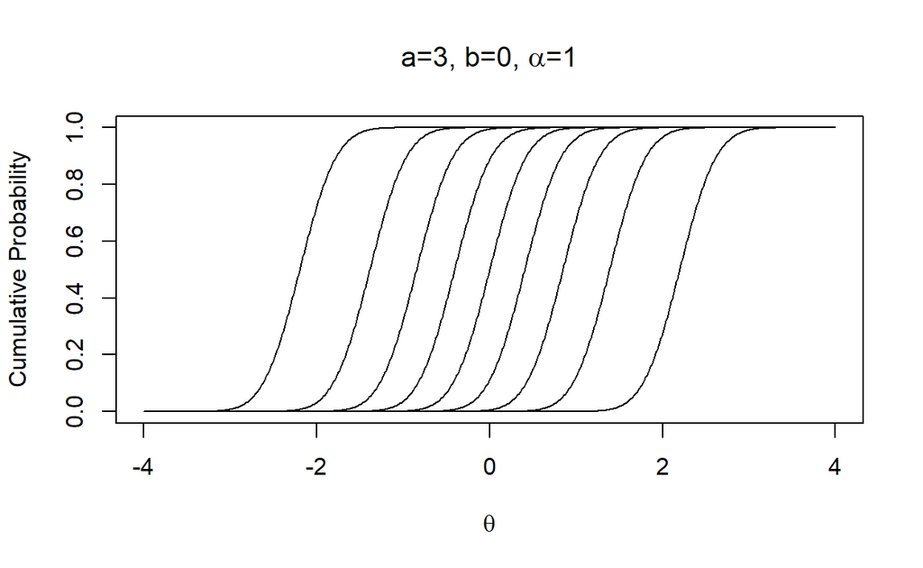

```r
 theta <- seq(-4,4,.01)

 a     = 3
 b     = 0
 alpha = 1

 x    <- 1
 k    <- 10
 v    <- a*(theta-b-(1/alpha)*log(x/(k-x)))
 plot(theta,pnorm(v,0,1),type="l",xlim=c(-4,4),ylim=c(0,1),
      main=expression(paste("a=3, b=0, ",alpha,"=1")),
      xlab=expression(theta),ylab="Cumulative Probability")

 for(x in 2:(k-1)){
     v    <- a*(theta-b-(1/alpha)*log(x/(k-x)))
     points(theta,pnorm(v,0,1),type="l")
 }
```

Or, we can keep everything the same but change the value of the parameter $b$ to -2, and we see the curves shift to left.

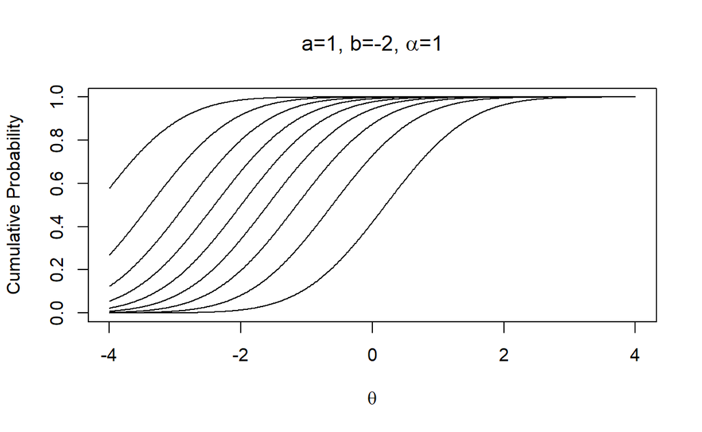

```r
 theta <- seq(-4,4,.01)

 a     = 1
 b     = -2
 alpha = 1

 x    <- 1
 k    <- 10
 v    <- a*(theta-b-(1/alpha)*log(x/(k-x)))
 plot(theta,pnorm(v,0,1),type="l",xlim=c(-4,4),ylim=c(0,1),
      main=expression(paste("a=1, b=-2, ",alpha,"=1")),
      xlab=expression(theta),ylab="Cumulative Probability")

 for(x in 2:(k-1)){
     v    <- a*(theta-b-(1/alpha)*log(x/(k-x)))
     points(theta,pnorm(v,0,1),type="l")
 }
```

Lastly, let’s change the value of the parameter $\alpha$ to 4, and we see the distance among curves gets smaller.

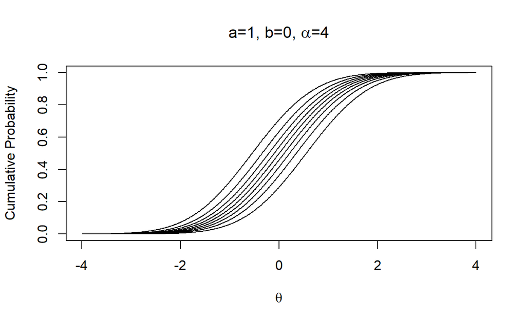

```r
 theta <- seq(-4,4,.01)

 a     = 1
 b     = 0
 alpha = 4

 x    <- 1
 k    <- 10
 v    <- a*(theta-b-(1/alpha)*log(x/(k-x)))
 plot(theta,pnorm(v,0,1),type="l",xlim=c(-4,4),ylim=c(0,1),
      main=expression(paste("a=1, b=0, ",alpha,"=4")),
      xlab=expression(theta),ylab="Cumulative Probability")

 for(x in 2:(k-1)){
     v    <- a*(theta-b-(1/alpha)*log(x/(k-x)))
     points(theta,pnorm(v,0,1),type="l")
 }
```

For those who are familiar with the Graded Response Model (GRM) may see the difference. In GRM, we estimate a step parameter for each response category, and these step parameters control the location of the operating characteristic curves and hence the distance among the curves at the same time. So, if there is an item with ten categories, GRM estimates nine step parameters. Instead, CRM estimates only two parameters ($b$ and $\alpha$) per item to control the location and distance among the curves regardless of the number of categories. So, CRM is a restricted version of GRM where we control the distance among the curves with only one parameter. If we think the $b$ parameter a kind of common difficulty parameter for an item, the term
$$\frac{1}{\alpha_j}ln\frac{x}{k-x})$$
decides how much each score is away from that common difficulty after accounting for the distance between the score and the maximum possible score.

Wang & Zeng (1998) also simplifies the equation by transforming the observed response (this is like a logit transformation for the observed responses),
$$Z=ln\frac{X}{k-X}$$
and provides the conditional PDF of Z as

$$f(z|\theta_i,a_j,b_j,\alpha_j)=\frac{a}{\alpha\sqrt{2\pi}}e^\frac{-(a_j(\theta_i-b_j-\frac{z_i}{\alpha_j}))^2}{2}$$
, which is a normal density function with a mean of $\alpha_j(\theta_i - b_j)$ and standard deviation of $\alpha_j/a_j$.

## Formatting Data for Stan

There are other tools we can use to fit CRM. I will focus here fitting the model using Stan, but I also provide two other tools at the very end as supplemental material. Before introducing the Stan model syntax, I should first reformat data as this is the only way to run Stan with missing data. Although I don’t have missing data in the ORF dataset used for this blog post, I force myself to use this procedure to get used to it.

```r
# Wide format data (2594 x 3) with rows representing a different individual and
# columns represent a different outcome

head(wpm)
```

```
  spas1wpm spas2wpm spas3wpm
1       66       74       74
2       33       30       29
3      101      117      110
4       14       12       11
5       22       17       23
6       47       53       38
```

```r
dim(wpm)
```

```
[1] 2594    3
```

```r
# add an arbitrary individual id variable

wpm$id <- 1:nrow(wpm)

# Convert the wide format data to long format (7782 x 3)
# This is like repeated measures data

wpm.long <- reshape(data      = wpm,
                  idvar       = "id",
                  varying     = list(colnames(wpm)[1:3]),
                  timevar     = "Item",
                  times       = 1:3,
                  v.names      = "score",
                  direction   = "long")


wpm.long <- wpm.long[order(wpm.long$id),]

head(wpm.long)
```

```
    id Item score
1.1  1    1    66
1.2  1    2    74
1.3  1    3    74
2.1  2    1    33
2.2  2    2    30
2.3  2    3    29
```

```r
dim(wpm.long)
```

```
[1] 7782    3
```

```r
  # Each individual is represented in three rows, one for each item
  # There are extra two columns for item and person id


# The next line doesn't change anything for this case as there is no
# missing data but this is critical step if you have missing data

wpm.long <- na.omit(wpm.long)


# Transform the observed scores to logits(from X to Z in the above description)
# This assumes each reading passage has 250 words so the
# maximum possible score is 250

wpm.long$score <- log(wpm.long$score/(250-wpm.long$score))

head(wpm.long)
```

```
    id Item      score
1.1  1    1 -1.0252810
1.2  1    2 -0.8664189
1.3  1    3 -0.8664189
2.1  2    1 -1.8833898
2.2  2    2 -1.9924302
2.3  2    3 -2.0308669
```

```r
# Create each column in the long format data as separate vectors
# These are what we will feed to Stan as our data

id            <- wpm.long$id
item          <- wpm.long$Item
score         <- wpm.long$score
n_obs         <- length(wpm.long)
```

## Stan Model Syntax

Below is the Stan model syntax for fitting CRM. I follow the guidelines in the Stan manual and imposes weakly-informative prior on model parameters.

```r
crm <- '

  data{
    int  J;                    //  number of items
    int  I;                    //  number of individuals
    int  n_obs;                //  number of observed responses
  int  item[n_obs];          //  item id
  int  id[n_obs];            //  person id
  real Y[n_obs];             //  vector of transformed outcome
 }

  parameters {

    vector[J] b;                 // vector of b parameters forJ items
      real mu_b;                 // mean of the b parameters
      real<lower=0> sigma_b;     // standard dev. of the b parameters

    vector<lower=0>[J] a;       // vector of a parameters for J items
      real mu_a;                 // mean of the a parameters
      real<lower=0> sigma_a;     // standard deviation of the a parameters

    vector<lower=0>[J] alpha;   // vector of alpha parameters for J items
      real mu_alpha;             // mean of alpha parameters
      real<lower=0> sigma_alpha; // standard deviation of alpha parameters

    vector[I] theta;             // vector of theta parameters for I individuals
  }

  model{

     mu_b     ~ normal(0,5);
     sigma_b  ~ cauchy(0,2.5);
         b    ~ normal(mu_b,sigma_b);

     mu_a    ~ normal(0,5);
     sigma_a ~ cauchy(0,2.5);
         a   ~ normal(mu_a,sigma_a);

     mu_alpha ~ normal(0,5);
     sigma_alpha ~ cauchy(0,2.5);
         alpha   ~ normal(mu_alpha,sigma_alpha);

     theta   ~ normal(0,1);      // The mean and variance of theta is fixed to 0 and 1
                                 // for model identification

      for(i in 1:n_obs) {
        Y[i] ~ normal(alpha[item[i]]*(theta[id[i]]-b[item[i]]),alpha[item[i]]/a[item[i]]);
       }
   }
'
```

## Fitting the Model

The code below fits the model with four chains and 50,000 iterations for each chain. By default, the first 50% of the iterations are used as warm-up and the remaining 50% of the iterations used for inference.

```r
require(rstan)

data <- list(I     = 2594,
             J     = 3,
             n_obs = 7782,
             id    = id,
             item  = item,
             Y     = score)

fit_crm <- stan(model_code = crm,
                data       = data,
                iter       = 50000,
                chains     = 4,
                control    = list(max_treedepth = 15,adapt_delta=0.9))
```

```r
print(get_elapsed_time(fit_crm))
```

```
         warmup  sample
chain:1 1227.35 1882.09
chain:2 1166.93 1942.92
chain:3 1273.22 1944.18
chain:4 1280.11 2007.22
```

```r
sum(get_elapsed_time(fit_crm))/3600    # how many hours it took to run the model with the
```

```
[1] 3.53445
```

```r
                                       # above settings
```

## Model Convergence

```r
print(fit_crm,
      pars = c("b","mu_b","sigma_b",
               "a","mu_a","sigma_a",
               "alpha","mu_alpha","sigma_alpha"),
      probs = c(0.025,0.975),
      digits = 3)
```

```
Inference for Stan model: ebc8a1e0d17f738279125cd2fac99954.
4 chains, each with iter=50000; warmup=25000; thin=1;
post-warmup draws per chain=25000, total post-warmup draws=1e+05.

             mean se_mean    sd  2.5% 97.5% n_eff  Rhat
b[1]        1.519   0.000 0.031 1.457 1.579  4892 1.001
b[2]        1.130   0.000 0.026 1.078 1.180  4295 1.001
b[3]        1.269   0.000 0.027 1.215 1.323  4421 1.001
mu_b        1.299   0.003 0.467 0.377 2.181 31652 1.000
sigma_b     0.571   0.004 0.671 0.121 2.311 28645 1.000
a[1]        3.201   0.001 0.075 3.057 3.350 15234 1.000
a[2]        5.164   0.001 0.175 4.835 5.521 17507 1.000
a[3]        4.604   0.001 0.136 4.347 4.880 18256 1.000
mu_a        4.107   0.005 1.164 1.424 6.176 57866 1.000
sigma_a     1.762   0.006 1.356 0.573 5.187 44796 1.000
alpha[1]    0.825   0.000 0.013 0.801 0.850  7178 1.000
alpha[2]    1.008   0.000 0.015 0.980 1.038  6663 1.000
alpha[3]    0.997   0.000 0.015 0.969 1.026  6645 1.000
mu_alpha    0.936   0.003 0.338 0.329 1.505 16201 1.000
sigma_alpha 0.359   0.004 0.521 0.063 1.672 19521 1.000

Samples were drawn using NUTS(diag_e) at Wed Feb 23 16:29:05 2022.
For each parameter, n_eff is a crude measure of effective sample size,
and Rhat is the potential scale reduction factor on split chains (at
convergence, Rhat=1).
```

It seems that we have convergence, and all chains yield consistent results as all $\hat{R}$ values are less than 1.01, The figures below are the posterior distributions for all these parameters. They all look fine.

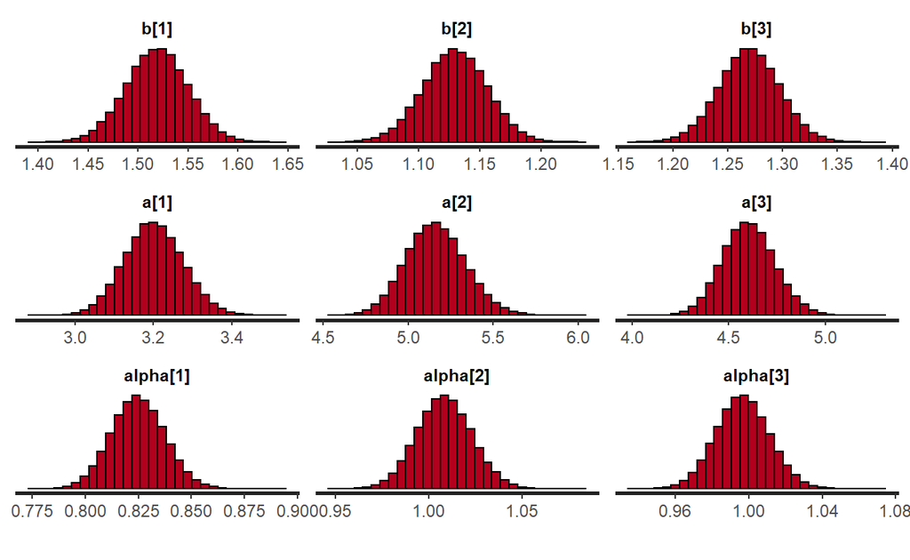

```r
plot(fit_crm,
     plotfun = "hist",
     pars = c("b[1]","b[2]","b[3]",
              "a[1]","a[2]","a[3]",
              "alpha[1]","alpha[2]","alpha[3]"),
     inc_warmup = FALSE)
```

I also used the recommendations provided [at this link](https://mc-stan.org/users/documentation/case-studies/rstan_workflow.html) to check some other things (seemed important). None of them indicated any red flag about the model convergence.

```r
source("https://raw.githubusercontent.com/betanalpha/knitr_case_studies/master/qr_regression/stan_utility.R")

check_treedepth(fit_crm,15)
```

```
[1] "0 of 100000 iterations saturated the maximum tree depth of 15 (0%)"
```

```r
check_energy(fit_crm)
```

```
[1] "E-BFMI indicated no pathological behavior"
```

```r
check_div(fit_crm)
```

```
[1] "0 of 100000 iterations ended with a divergence (0%)"
```

# Parameter Interpretation

```r
b     <- summary(fit_crm)$summary[1:3,1]

b
```

```
    b[1]     b[2]     b[3]
1.518776 1.129768 1.269264
```

```r
a     <- summary(fit_crm)$summary[6:8,1]

a
```

```
    a[1]     a[2]     a[3]
3.201176 5.164072 4.604099
```

```r
alpha <- summary(fit_crm)$summary[11:13,1]

alpha
```

```
 alpha[1]  alpha[2]  alpha[3]
0.8249487 1.0083558 0.9966818
```

```r
thetas = summary(fit_crm)$summary[16:2609,1]
```

The $b$ parameters for three reading passages in this dataset were 1.52, 1.13, 1.27. I think it is fair to call them “reading passage difficulty” in this context. Given that we fix the mean and variance of the latent person parameter ($\theta$) to 0 and 1, we can compare the passage difficulty relative to the levels of individuals. Note that $\theta$ represents here a latent variable indicating oral reading fluency. So, these three reading passages seem very difficult compared to the ORF levels of these individuals.

The $a$ parameters were 3.2, 5.16, 4.6. We can call them “reading passage discrimination” parameters. So, these reading passages are highly informative about the latent construct being measured. These very high discrimination parameters are not very surprising, given that the correlations among the three variables were 0.94, 0.94, and 0.96.

The $\alpha$ parameters were 0.82, 1.01, 1. I think it would be wise to go back and fix all the $\alpha$ parameters to 1 in the model and then re-fit, but I will not do it. Note that the $\alpha$ scales the distance between the response categories.

We can plot the operating characteristic curves, but it would be too messy for all 250 score categories, However, I can draw it for $P(X\geq 50)$, $P(X\geq 100)$, $P(X\geq 150)$, …, $P(X\geq 200)$. Below is the plot for Item 1.

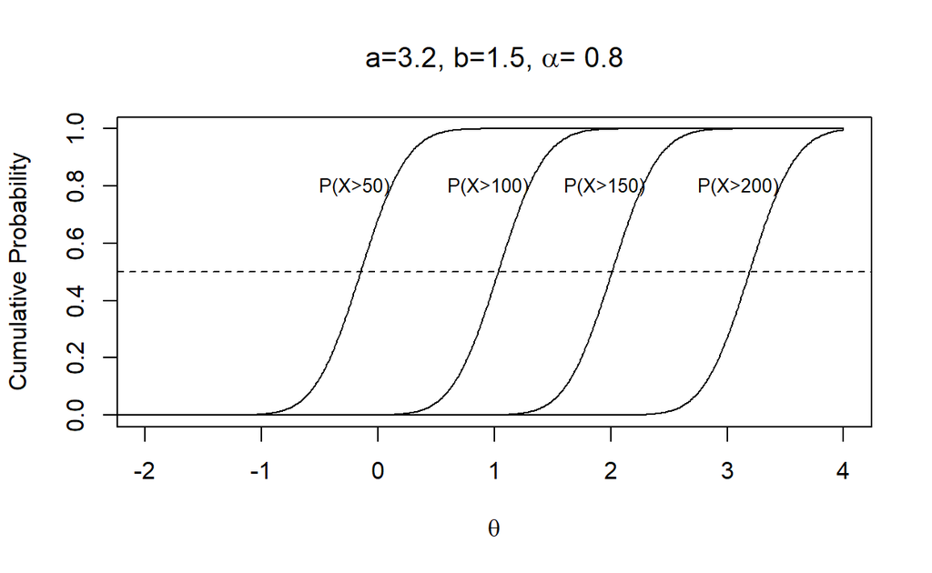

```r
 theta <- seq(-4,4,.01)

 a1     = 3.20
 b1     = 1.52
 alpha1 = 0.83

 x    <- 50
 k    <- 250
 v    <- a1*(theta-b1-(1/alpha1)*log(x/(k-x)))

 plot(theta,pnorm(v,0,1),type="l",xlim=c(-2,4),ylim=c(0,1),
      main=expression(paste("a=3.2, b=1.5, ",alpha,"= 0.8")),
      xlab=expression(theta),ylab="Cumulative Probability")

 for(x in c(100,150,200)){
     v    <- a1*(theta-b1-(1/alpha1)*log(x/(k-x)))
     points(theta,pnorm(v,0,1),type="l")
 }

 abline(h=.5,lty=2)

 text(-0.2,.8,"P(X>50)",cex=0.8)
 text(0.95,.8,"P(X>100)",cex=0.8)
 text(1.95,.8,"P(X>150)",cex=0.8)
 text(3.1,.8,"P(X>200)",cex=0.8)
```

Let’s check the latent person parameter estimates.

```r
thetas = summary(fit_crm)$summary[16:2609,1]

psych::describe(thetas)
```

```
   vars    n mean   sd median trimmed  mad   min  max range skew
X1    1 2594    0 0.99   0.05       0 1.07 -2.55 3.45  6.01 0.05
   kurtosis   se
X1     -0.4 0.02
```

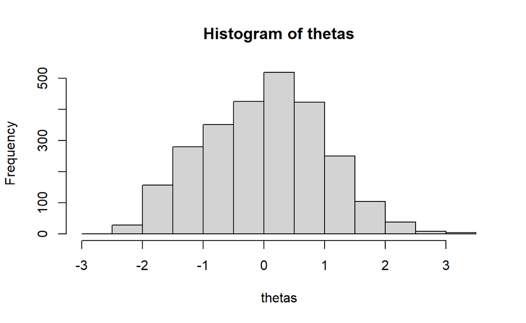

```r
hist(thetas)
```

As expected, the estimates have a mean of 0 and a standard deviation of .99.

Lower estimates indicate lower levels of oral reading fluency, and higher estimates indicate higher levels of oral reading fluency.

We can have a better understanding if we check a few individuals.

```r
low = order(thetas,decreasing=F)[1:5]
high = order(thetas,decreasing=T)[1:5]

# The individuals with the highest oral reading fluency and their reading scores

cbind(wpm[high,],thetas[high])
```

```
     spas1wpm spas2wpm spas3wpm   id thetas[high]
1472      200      234      221 1298     3.451058
800       183      236      212  708     3.321318
2395      176      234      210 2165     3.207132
1266      159      227      227 1108     3.193841
2308      181      224      220 2084     3.111148
```

```r
# The individuals with the lowest oral reading fluency and their reading scores

cbind(wpm[low,],thetas[low])
```

```
     spas1wpm spas2wpm spas3wpm   id thetas[low]
2349       18        6        3 2121   -2.554590
1254       11        7        4 1097   -2.488763
666         2        3       34  584   -2.423383
1101       12        6        8  957   -2.284357
502        11        7        7  437   -2.282513
```

For instance, the model provides an estimate of 3.11 for a student who had read 181 words, 224 words, and 220 words and an estimate of -2.28 for a student who had read 12 words, six words, and eight words in the three reading passages, respectively. We can check how the estimated theta is related to the scores from each reading passage for all examinees.

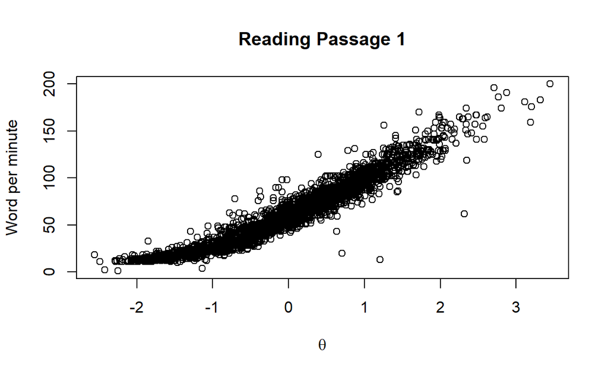

```r
plot(thetas,wpm[,1],xlab=expression(theta),ylab="Word per minute",main="Reading Passage 1")
```

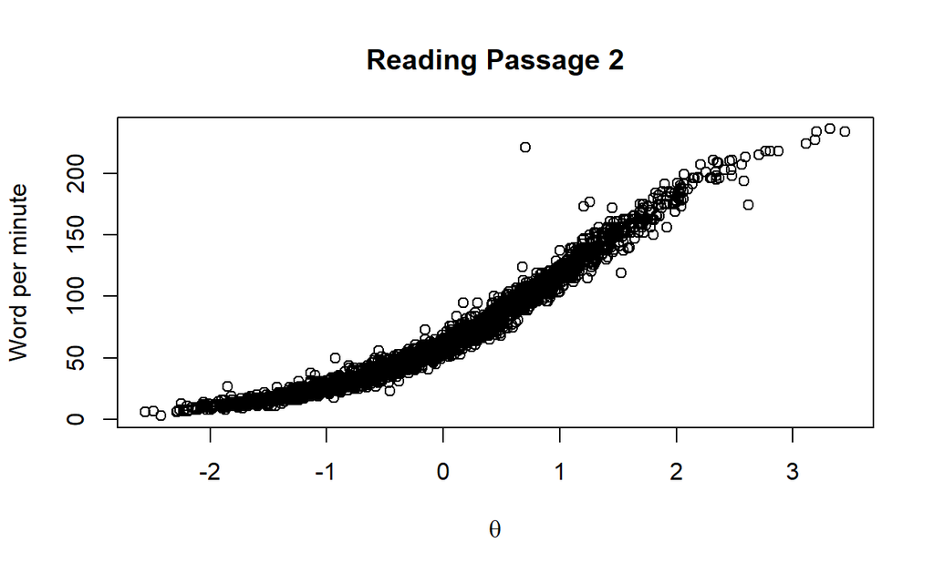

```r
plot(thetas,wpm[,2],xlab=expression(theta),ylab="Word per minute",main="Reading Passage 2")
```

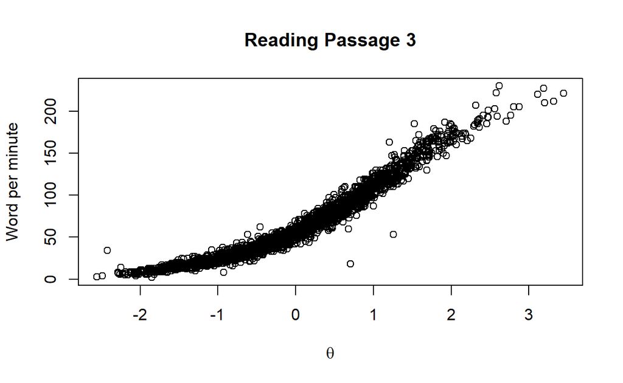

```r
plot(thetas,wpm[,3],xlab=expression(theta),ylab="Word per minute",main="Reading Passage 3")
```

It is not surprising to see that there is a strong relationship because of the high discrimination parameters. Note that the relationship is not linear as we model the relationship between $\theta$ and $ln\frac{x}{k-x}$

# Model Fit Assessment

The first thing I would like to look at is how well the model predicts the observed ORF scores. Treating the item and person parameter estimates as known, we can calculate a predicted score on each item for each individual as well as a standardized residual.

Note that I mentioned before that the conditional PDF of Z is a normal density function with a mean of $\alpha_j(\theta_i - b_j)$ and standard deviation of $\alpha_j/a_j$, where Z is defined as
$$ln\frac{X}{k-X}$$
.

```r
# Remember the data with observed outcomes

head(wpm.long)
```

```
    id Item      score
1.1  1    1 -1.0252810
1.2  1    2 -0.8664189
1.3  1    3 -0.8664189
2.1  2    1 -1.8833898
2.2  2    2 -1.9924302
2.3  2    3 -2.0308669
```

```r
# For each observation, compute the model prediction

wpm.long$pred <- NA
wpm.long$sres <- NA

for(i in 1:nrow(wpm.long)){

      wpm.long[i,]$pred = alpha[wpm.long[i,2]]*(thetas[wpm.long[i,1]]-b[wpm.long[i,2]])

      wpm.long[i,]$sres = (wpm.long[i,]$score-wpm.long[i,]$pred)/(alpha[wpm.long[i,2]]/a[wpm.long[i,2]])

}

head(wpm.long)
```

```
    id Item      score       pred        sres
1.1  1    1 -1.0252810 -0.9947824 -0.11834838
1.2  1    2 -0.8664189 -0.8236896 -0.21882874
1.3  1    3 -0.8664189 -0.9531861  0.40081459
2.1  2    1 -1.8833898 -1.9047571  0.08291486
2.2  2    2 -1.9924302 -1.9359749 -0.28912342
2.3  2    3 -2.0308669 -2.0525941  0.10036738
```

Note that the observed values and predicted values are on a logit metric because of the transformation. Let’s check the correlation between observed outcomes and model predicted outcomes for each item.

```r
cor(wpm.long[wpm.long$Item==1,c("score","pred")])
```

```
          score      pred
score 1.0000000 0.9625937
pred  0.9625937 1.0000000
```

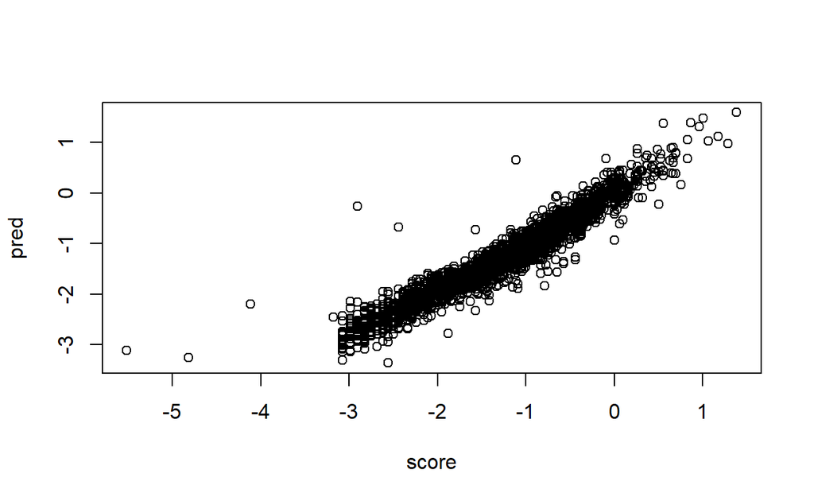

```r
plot(wpm.long[wpm.long$Item==1,c("score","pred")])
```

```r
cor(wpm.long[wpm.long$Item==2,c("score","pred")])
```

```
          score      pred
score 1.0000000 0.9901743
pred  0.9901743 1.0000000
```

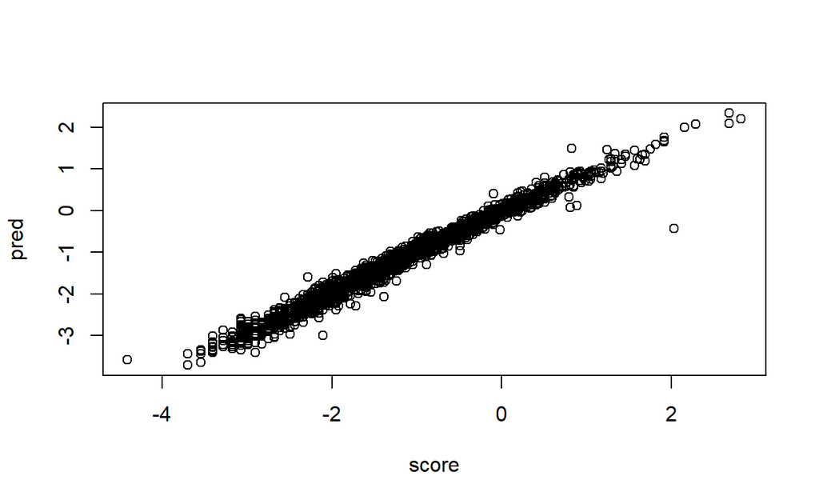

```r
plot(wpm.long[wpm.long$Item==2,c("score","pred")])
```

```r
cor(wpm.long[wpm.long$Item==3,c("score","pred")])
```

```
          score      pred
score 1.0000000 0.9855805
pred  0.9855805 1.0000000
```

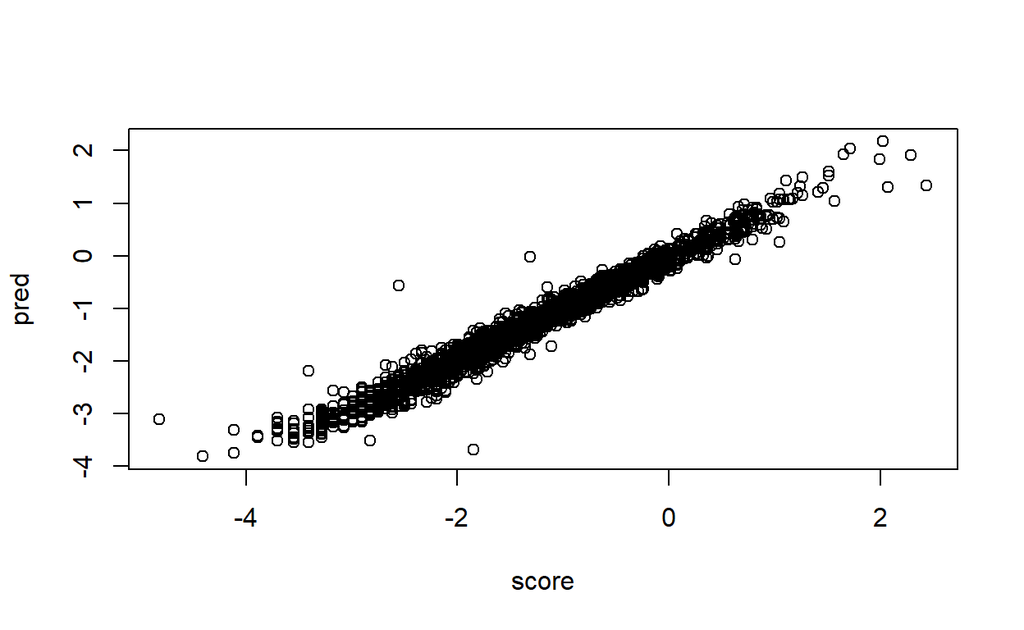

```r
plot(wpm.long[wpm.long$Item==3,c("score","pred")])
```

It looks like the model predicts the observed outcomes pretty well.

We can also check if there is any systematic relationship between residuals and the latent variable.

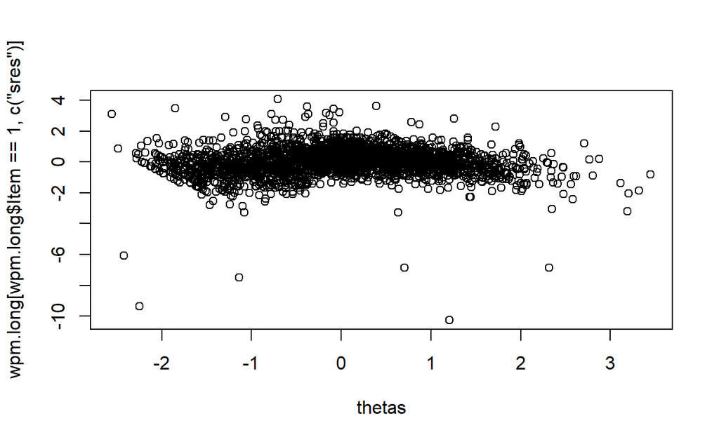

```r
plot(thetas,wpm.long[wpm.long$Item==1,c("sres")])
```

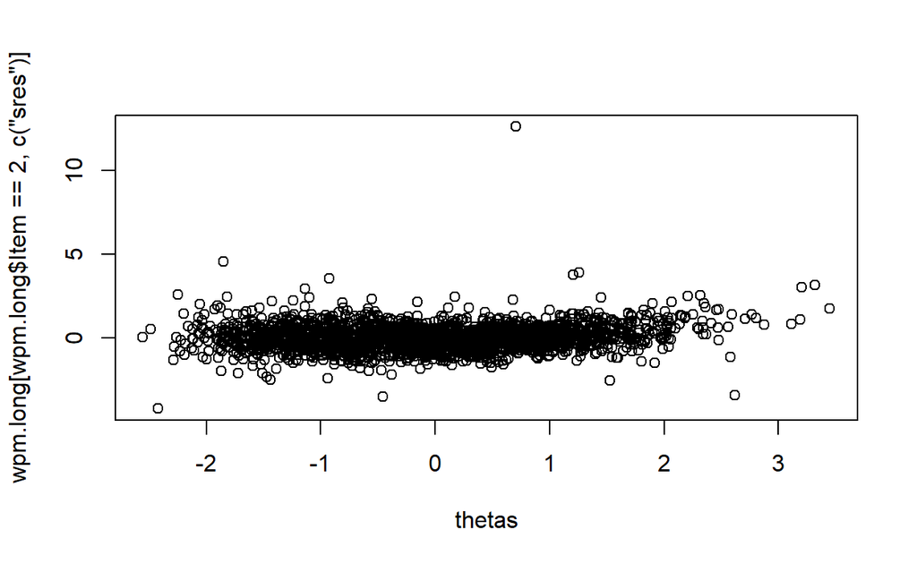

```r
plot(thetas,wpm.long[wpm.long$Item==2,c("sres")])
```

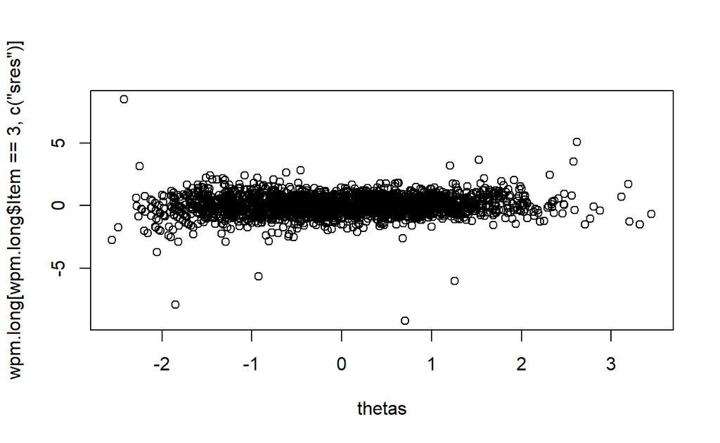

```r
plot(thetas,wpm.long[wpm.long$Item==3,c("sres")])
```

There are some individuals with extreme residuals for each item; however, there doesn’t seem to be any systematic pattern between residuals and the latent variable.

We can also check the distribution of standardized residuals within each item.

```r
psych::describeBy(wpm.long$sres,wpm.long$Item)
```

```
 Descriptive statistics by group
group: 1
   vars    n mean   sd median trimmed  mad    min  max range  skew
X1    1 2594    0 0.91   0.04    0.01 0.76 -10.26 4.06 14.32 -1.49
   kurtosis   se
X1    15.59 0.02
----------------------------------------------------
group: 2
   vars    n mean   sd median trimmed  mad   min   max range skew
X1    1 2594    0 0.74  -0.01   -0.01 0.63 -4.24 12.61 16.85 2.14
   kurtosis   se
X1    34.15 0.01
----------------------------------------------------
group: 3
   vars    n mean  sd median trimmed  mad  min  max range  skew
X1    1 2594    0 0.8   0.02    0.01 0.66 -9.2 8.46 17.66 -0.71
   kurtosis   se
X1    18.05 0.02
```

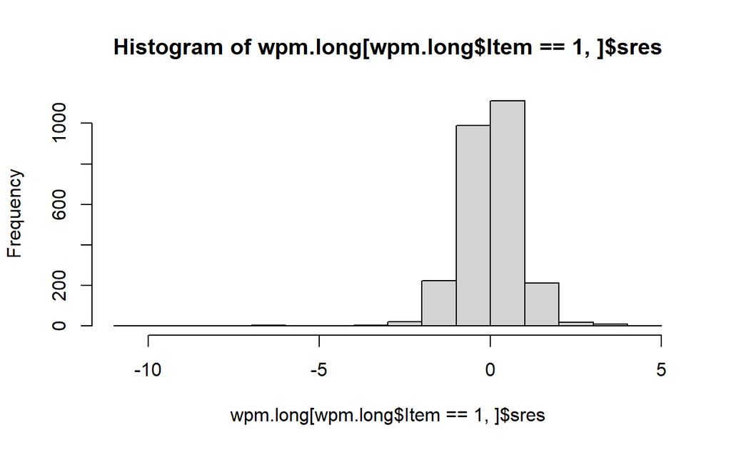

```r
hist(wpm.long[wpm.long$Item==1,]$sres)
```

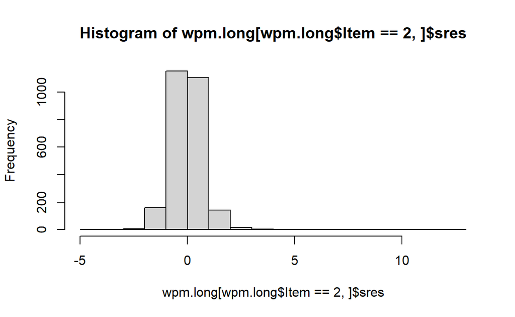

```r
hist(wpm.long[wpm.long$Item==2,]$sres)
```

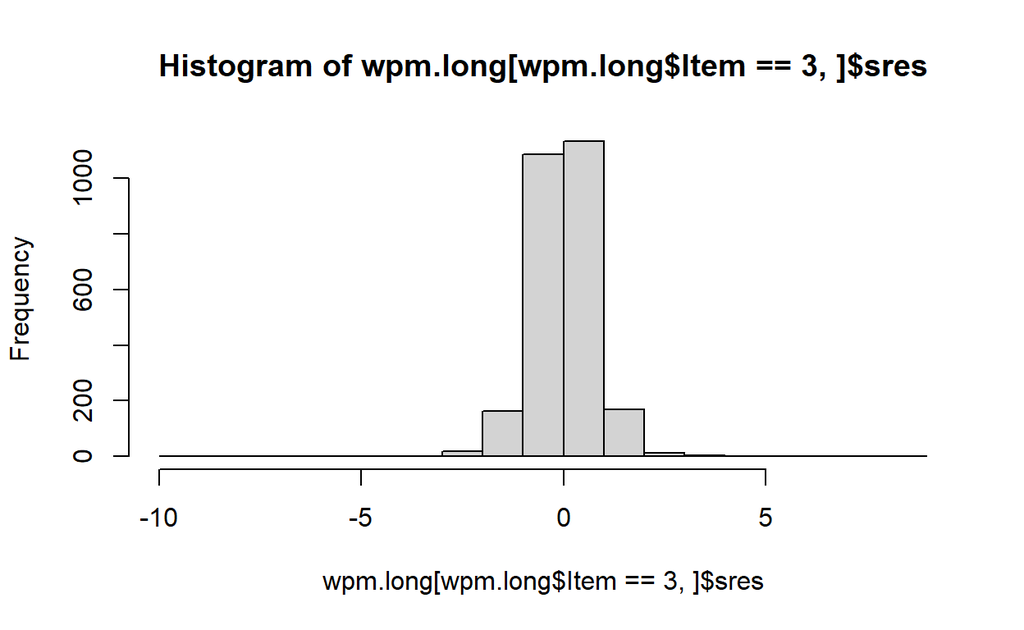

```r
hist(wpm.long[wpm.long$Item==3,]$sres)
```

There are some extreme residuals we may want to look deeper. So, let’s filter the observations with a standardized residual outside of the range [-4,4] and look at their response pattern.

```r
outliers = which(abs(wpm.long$sres)>4)

length(outliers)
```

```
[1] 16
```

```r
wpm.long[outliers,]
```

```
         id Item      score        pred       sres
386.2   386    2 -2.1113349 -3.00178168   4.560227
386.3   386    3 -4.8202816 -3.10606181  -7.918713
584.1   584    1 -4.8202816 -3.25207870  -6.085341
584.2   584    2 -4.4107760 -3.58284045  -4.240089
584.3   584    3 -1.8489179 -3.68039351   8.460367
591.1   591    1 -5.5174529 -3.10658824  -9.355252
604.1   604    1 -4.1190372 -2.19143516  -7.479973
919.1   919    1 -2.4423470 -0.67317488  -6.865193
919.2   919    2  2.0308669 -0.43058046  12.605759
919.3   919    3 -2.5563656 -0.56462807  -9.200686
934.3   934    3 -3.4094962 -2.18899591  -5.638012
1154.3 1154    3  2.4423470  1.34338758   5.076563
1911.1 1911    1 -1.1093076  0.65750975  -6.856055
1929.3 1929    3 -1.3129118 -0.01116754  -6.013312
2032.1 2032    1 -0.7907857 -1.83740383   4.061355
2222.1 2222    1 -2.9031108 -0.25823770 -10.263311
```

```r
outlier.ids <- unique(wpm.long[outliers,]$id)

outlier.ids
```

```
 [1]  386  584  591  604  919  934 1154 1911 1929 2032 2222
```

```r
wpm[outlier.ids,]
```

```
     spas1wpm spas2wpm spas3wpm   id
443        33       27        2  386
666         2        3       34  584
673         1       13       14  591
686         4       38       29  604
1052       20      221       18  919
1068       47       50        8  934
1316      165      174      230 1154
2122       62      211      207 1911
2144      156      177       53 1929
2253       78       30       20 2032
2453       13      173      163 2222
```

After removing the outliers, the standardized residuals follow an approximately normal distribution.

```r
psych::describeBy(wpm.long[-outliers,]$sres,wpm.long[-outliers,]$Item)
```

```
 Descriptive statistics by group
group: 1
   vars    n mean   sd median trimmed  mad   min  max range skew
X1    1 2587 0.02 0.82   0.05    0.02 0.76 -3.28 3.62   6.9  0.1
   kurtosis   se
X1     1.25 0.02
----------------------------------------------------
group: 2
   vars    n mean   sd median trimmed  mad   min  max range skew
X1    1 2591    0 0.69  -0.01   -0.02 0.62 -3.53 3.87  7.41  0.3
   kurtosis   se
X1     2.19 0.01
----------------------------------------------------
group: 3
   vars    n mean   sd median trimmed  mad   min  max range  skew
X1    1 2588 0.01 0.72   0.02    0.01 0.66 -3.72 3.64  7.36 -0.03
   kurtosis   se
X1     1.61 0.01
```

A final check could be the residual correlations. As we assume local independence (and/or unidimensionality), the correlations among the reading scores should be ideally 0 once we account for the latent oral reading fluency parameter in the model.

```r
cor(wpm.long[wpm.long$Item==1,c("sres")],wpm.long[wpm.long$Item==2,c("sres")])
```

```
[1] -0.4148556
```

```r
cor(wpm.long[wpm.long$Item==1,c("sres")],wpm.long[wpm.long$Item==3,c("sres")])
```

```
[1] -0.3441612
```

```r
cor(wpm.long[wpm.long$Item==2,c("sres")],wpm.long[wpm.long$Item==3,c("sres")])
```

```
[1] -0.6774124
```

The high residual correlations were the only thing I was not happy about this model. I don’t know why the correlations among the residuals are unusually high. This suggests that there is still some variation left unexplained after accounting for one latent variable. This might suggest a second (latent) variable, but I don’t think there is much I can do here to improve the model with only three items. I guess I’ll just live with this.

## APPENDIX A: Alternative Ways of Fitting the Continuous Response Model

### 1. Heuristic Estimation through Linear Factor Model

The heuristic estimation is a method used by [Bejar (1977)](https://journals.sagepub.com/doi/abs/10.1177/014662167700100407) and also discussed in detail by [Ferrando(2002)](https://www.tandfonline.com/doi/abs/10.1207/S15327906MBR3704_05). It is very convenient as you can fit this model with any SEM software, so it is also easy to extend the model to multiple-group, multidimensional, or mixture cases, [see this paper I worked on for mixture extension of CRM](https://journals.sagepub.com/doi/full/10.1177/0013164419856663).

In this approach, you can first transform the observed scores ($X$) using the equation $ln\frac{X}{k-X}$. Then, you can fit a simple linear factor model to the transformed scores. Finally, you put the model parameter estimates back to IRT metric. Below is a quick implementation in the lavaan package.

```r
wpm.transformed <- log(wpm[,1:3]/(250-wpm[,1:3]))

head(wpm.transformed)
```

```
    spas1wpm   spas2wpm   spas3wpm
1 -1.0252810 -0.8664189 -0.8664189
2 -1.8833898 -1.9924302 -2.0308669
3 -0.3888258 -0.1281752 -0.2411621
4 -2.8247745 -2.9873640 -3.0785683
5 -2.3383032 -2.6178251 -2.2894558
6 -1.4630584 -1.3129118 -1.7190001
```

```r
require(lavaan)


lfm <- 'f1 =~ NA*spas1wpm + l2*spas2wpm + l3*spas3wpm

        spas1wpm ~~ r1*spas1wpm
        spas2wpm ~~ r2*spas2wpm
        spas3wpm ~~ r3*spas3wpm

        f1 ~~ 1*f1'

fit <- cfa(model  = lfm,
           data   = wpm.transformed)

parameterEstimates(fit)
```

```
       lhs op      rhs label   est    se      z pvalue ci.lower
1       f1 =~ spas1wpm       0.824 0.013 65.728      0    0.800
2       f1 =~ spas2wpm    l2 1.008 0.015 69.316      0    0.980
3       f1 =~ spas3wpm    l3 0.996 0.015 68.688      0    0.968
4 spas1wpm ~~ spas1wpm    r1 0.066 0.002 29.168      0    0.062
5 spas2wpm ~~ spas2wpm    r2 0.038 0.002 16.793      0    0.034
6 spas3wpm ~~ spas3wpm    r3 0.047 0.002 19.980      0    0.042
7       f1 ~~       f1       1.000 0.000     NA     NA    1.000
  ci.upper
1    0.849
2    1.037
3    1.025
4    0.071
5    0.042
6    0.052
7    1.000
```

```r
intercepts <- colMeans(wpm.transformed)

intercepts
```

```
 spas1wpm  spas2wpm  spas3wpm
-1.252865 -1.139123 -1.264952
```

Once you estimate the parameters from the linear factor model, then you can transform them back to the IRT metric.

The unstandardized factor loadings (0.824, 1.008, and 0.996) correspond to the $\alpha$ parameters in CRM. You can check back the estimates from Stan, and you will see that they are identical.

If you divide the unstandardized factor loadings by residual standard deviation, you will get the discrimination parameters ($a$) of CRM.

$$\frac{0.824}{\sqrt{0.066}} = 3.21$$
$$\frac{1.008}{\sqrt{0.038}} = 5.18$$
$$\frac{0.996}{\sqrt{0.047}} = 4.59$$

Again, if you check the estimates for $a$ parameters we obtained from Stan, they are almost identical.

Finally, if you divide the intercepts by the unstandardized factor loadings and then multiply the result by -1, that should give you the difficulty parameters of CRM ($b$).

$$-\frac{-1.253}{0.824} = 1.52$$
$$-\frac{-1.139}{1.008} = 1.13$$
$$-\frac{-1.265}{0.996} = 1.27$$

Similarly, these values are almost identical to $b$ parameters obtained from Stan fit.

Another bonus is that you can also extract the factor scores from the lavaan object for each individual, and these factor scores should be almost identical to the $\theta$ estimates obtained from Stan fit.

```r
fscores <- lavPredict(fit)

psych::describe(fscores)
```

```
   vars    n mean   sd median trimmed  mad   min  max range skew
X1    1 2594    0 0.99   0.05       0 1.07 -2.56 3.45  6.01 0.05
   kurtosis   se
X1    -0.39 0.02
```

```r
cor(thetas,fscores)
```

```
            f1
[1,] 0.9999999
```

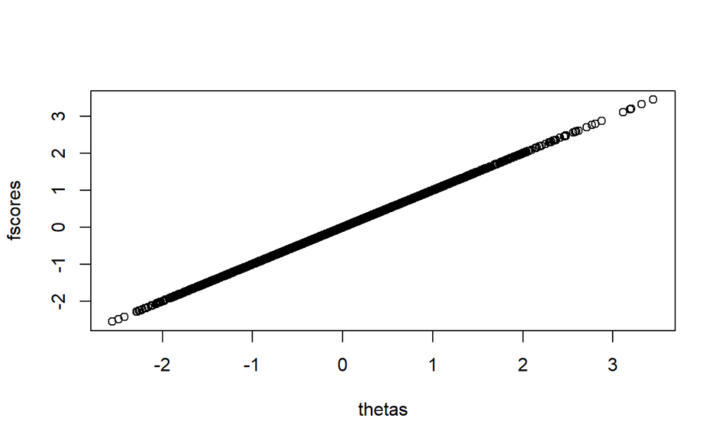

```r
plot(thetas,fscores)
```

### 2, Full-information Marginal Maximum Likelihood Estimation

This approach is fully described in two papers, [Wang and Zeng (1998)](https://journals.sagepub.com/doi/abs/10.1177/014662169802200402) and [Shojima(2005)](https://www.jstage.jst.go.jp/article/etr/28/1-2/28_KJ00003899231/_pdf/-char/ja). Wang and Zeng (1998) is a classical implementation of EM algorithm. However, Shojima(2005) is a really interesting paper as he derives the closed-form equation for the marginal likelihood, so there is no integration needed for the E-step. When I was first interested in this model, I created an R package, [EstCRM](https://cran.r-project.org/web/packages/EstCRM/index.html), that implements both approaches. Below is a code using this package to fit the model.

```r
require(EstCRM)

CRM <- EstCRMitem(wpm[,1:3],
                  max.item=c(250,250,250),
                  min.item=c(0,0,0),
                  max.EMCycle=500,
                  converge=.01,
                  type="Wang&Zeng",
                  BFGS=TRUE)

CRM$param
```

```
         [,1]     [,2]      [,3]
[1,] 3.090524 1.598122 0.7918418
[2,] 4.896383 1.192894 0.9677061
[3,] 4.470768 1.336568 0.9575835
```

Here it is! Again, we get almost identical estimates for item parameters. It is also possible to compute $\theta$ and compare them from the person parameter estimates from the previous two approaches (Stan and lavaan).

```r
theta.CRM <- EstCRMperson(data     = wpm[,1:3],
                          ipar     = CRM$param,
                          max.item = c(250,250,250),
                          min.item = c(0,0,0))

psych::describe(theta.CRM[[1]][,2])
```

```
   vars    n mean sd median trimmed  mad   min  max range skew
X1    1 2594    0  1   0.05       0 1.08 -2.58 3.48  6.06 0.04
   kurtosis   se
X1     -0.4 0.02
```

```r
cor(cbind(thetas,fscores,theta.CRM[[1]][,2]))
```

```
          thetas        f1
thetas 1.0000000 0.9999999 0.9999961
f1     0.9999999 1.0000000 0.9999949
       0.9999961 0.9999949 1.0000000
```